# Arbeidskrav 4

Lars Nymoen

20 11 2020

### DEL 2

## Introduksjon

Antall set på en treningsøvelse er også noe man må ta stilling til, hvis man ønsker å oppnå best mulig resultater. En tidligere studie fant at 3 set ga større styrkeøkning i peak torqu Nm enn det 1 ett gjorde (Munn, Herbert, Hancock & Gandevia, 2005). To annen studie støtter også dette synet (Paulsen, Myklestad & Raastad, 1996; Kramer et al, 1997).  
Min hypotese er at beinet der det er trent med 3 sett vil få en større økning i peak torque (Nm) til post i styrke enn gruppen som kun gjennomfører ett sett.

## Metode

I denne delen er det brukt en studie som hadde 34 deltakere (menn = 16, kvinner = 18), disse ble randomisert og skulle gjennomføre alle øvelsene forskjellig på hvert bein. Det ene skulle gjennomføre ett sett, mens det andre skulle gjennomføre 3 sett. Studien var en randomisert within-subject design. Øvelsene deltakerne skulle gjennomføre var isokinetisk legekstensjon der de presser på en stang som beveger seg med en gitt hastighet (60, 120 eller 240 grader i sekundet) og en øvelse som var isometrisk, der stanga står stille. Intervensjonen varte i 8 uker der deltakerne trente 3 ganger i uken på underkroppsøvelser.

# Statistikk

```
## Linear mixed model fit by REML ['lmerMod']
## Formula: load ~ timepoint * group + (1 | subject)
##    Data: isok.data
## REML criterion at convergence: 649.1161
## Random effects:
##  Groups   Name        Std.Dev.
##  subject  (Intercept) 51.46
##  Residual             16.69
## Number of obs: 68, groups:  subject, 34
## Fixed Effects:
##                 (Intercept)                timepointpost
##                     182.059                        7.471
##               groupmultiple  timepointpost:groupmultiple
##                      -7.941                       24.176
```

Tabell 1

[output not shown]

Tabell 1 viser utgangsverdi med endringer for de to testtidspunktene, standard error, t verdi og konfidensintervall.

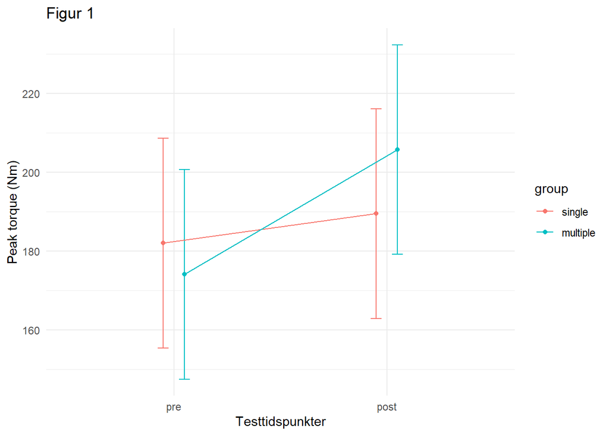

Grafen viser økning i Peak torque Nm fra pre til post for begge grupper, med konfidensintervall.

## Resultat

Fra testtidspunkt pre til post økte 3 set-gruppen med 31,7 Nm fra 174,1 Nm til 205,8 Nm (Tabell 1). 1 set-gruppen økte gruppen med 7,5 Nm fra 182,1 Nm til 189,6 Nm (Tabell 1), fra testtidspunkt pre til post.

## Diskusjon/konklusjon

I denne studien ser vi at det gir større økning i peak torque Nm ved å trene med 3 set versus å trene med kun 1 set, disse resultatene støttes av flere andre studier (Paulsen et al, 1996; Munn et al, 2005; Kramer et al, 1997)

## Referanser

Munn, JoanneE,. Herbert, Robert D,. Hancock, Mark J,. Gandevia, Simon C. (2005). Resistance Training for Strength: Effect of Number of Sets and Contraction Speed. *Medicine & Science in Sports & Exercise*, 37(9), 1622–1626. doi:10.1249/01.mss.0000177583.41245.f8

M. Bottaro; J. Veloso; D. Wagner; P. Gentil (2011). Resistance training for strength and muscle thickness: Effect of number of sets and muscle group trained. , 26(5), 0–264. doi:10.1016/j.scispo.2010.09.009

Paulsen, Gøran,. Myklestad Dag,. Raastad Truls. (1996). The Influence of Volume of Exercise on Early. Adaptations to Strength Training *Journal of Strength and Conditioning Research*, 2003, 17(1), 115–120

Kramer, J. B., Stone, M. H., O’Bryant, H. S., Conley, M. S., Johnson, R. L., Nieman, D. C., … & Hoke, T. P. (1997). Effects of single vs. multiple sets of weight training: impact of volume, intensity, and variation. *Journal of strength and Conditioning Research*, 11, 143-147.